# SNAG: Hormones

Shuying Yu

4/11/2022

# Overview

Data has been cleaned into tidy format prior to analysis.

For hormones and behavior correlations, I want to keep participants that have 1) SNAG data *and* 2) hormones data. Men and women will be kept separate for analyses because they were tested for different sex steroid hormones.

Men were tested for SHBG, DHEAS, and testosterone if they had a scan. If they did a follow-up spatial session or had no scan, they were only tested for SHBG and testosterone.

Women were tested for SHBG, DHEAS, testosterone, *and* estradiol, progestoerone, and FSH if they also did scan. If they did a follow-up spatial session, they were only tested for estradiol and testosterone. Only estradiol was tested if they did not do a scan, so some women may not be represented in the correlational data.

# Correlations

Current sample sizes for behavior $\times$ sex hormones (participants with behavior for analysis):

**Table 1.** Sample sizes for participants who have useable data for LOOP, MAZE, and DP broken down by sex.

| Sex | LOOP | MAZE | DSP |
| --- | --- | --- | --- |
| Female | 32 | 64 | 47 |
| Male | 22 | 23 | 30 |

The following figures and Pearson’s *r* correlation analyses are preliminary and exploratory. The hormone data were taken from when the SNAG study coincided with the blood draws (i.e., if participants did a follow-up SNAG, hormone data was taken from that time point and not when scan was done). See summary section for future considerations. Thus, sample sizes differ not just by task, but also by sex hormone.

The 95% confidence interval is drawn with the line of best fit. Data points with missing hormone data are not plotted (dropped automatically) so they do not skew the correlation analyses or the line of best fit.

## Male

### LOOP

**Position Error**

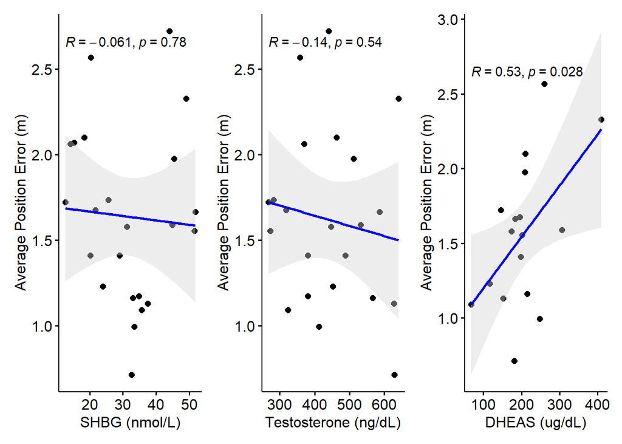

For LOOP position error, DHEAS seems to be positively associated with behavior for men.

**Degrees Traveled**

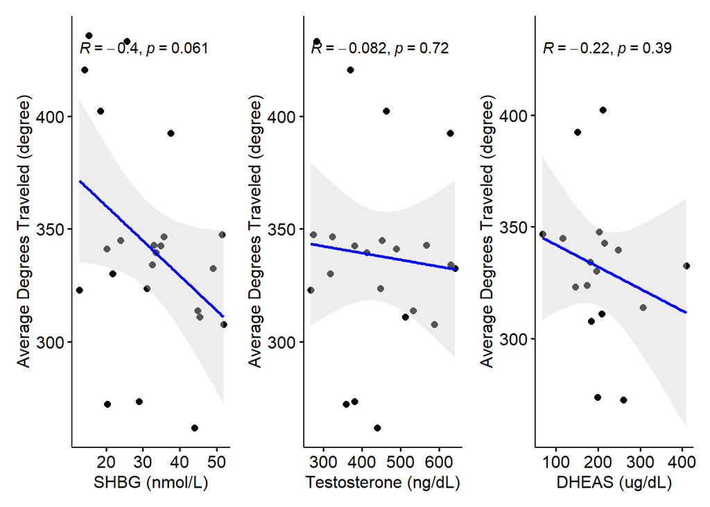

For LOOP degrees traveled, it seems to have a negative trend with hormones overall in men. SHBG seems to be marginally and negatively correlated with degrees traveled.

### MAZE

**Accuracy**

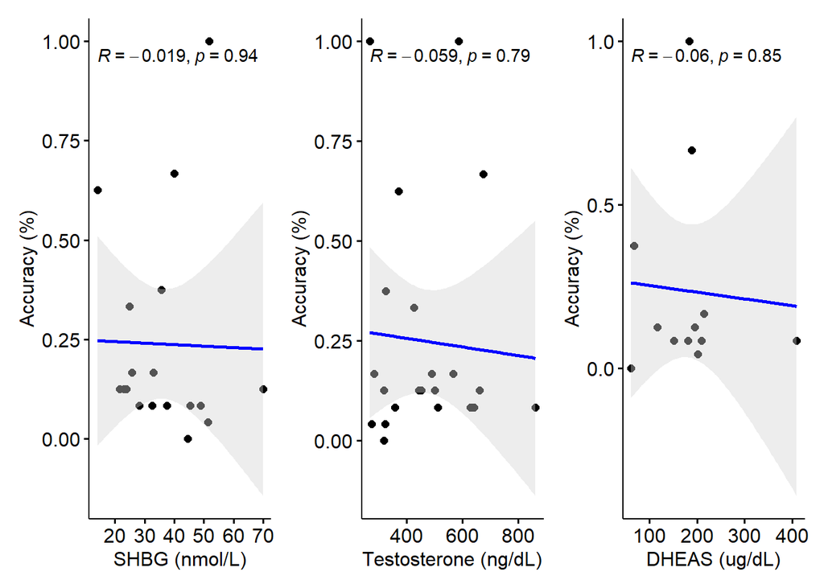

No associations between MAZE accuracy and hormones for men.

**Moves**

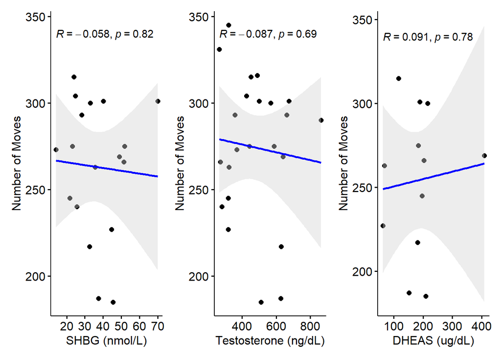

Also no association between MAZE number of moves and hormones for men.

### DSP

**Wayfinding Success**

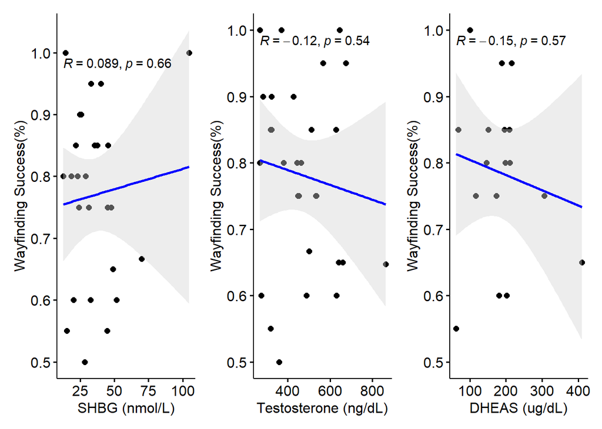

Overall no associations between DSP wayfinding success and hormones for men.

**Solution Index**

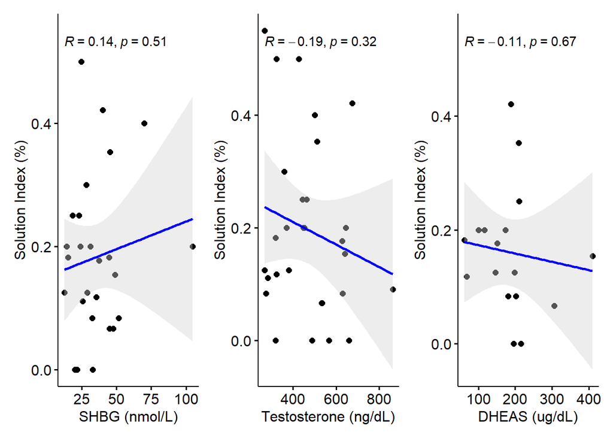

No association between DSP solution index and hormones for men.

## Female

### LOOP

**Position Error**

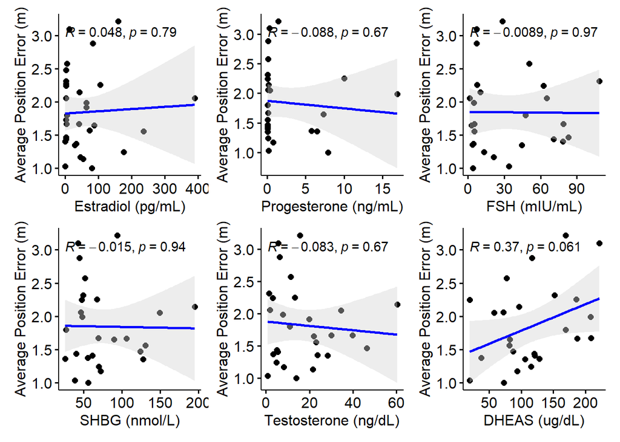

For LOOP position error, there is a positive marginal trend with DHEAS for women.

**Degrees Traveled**

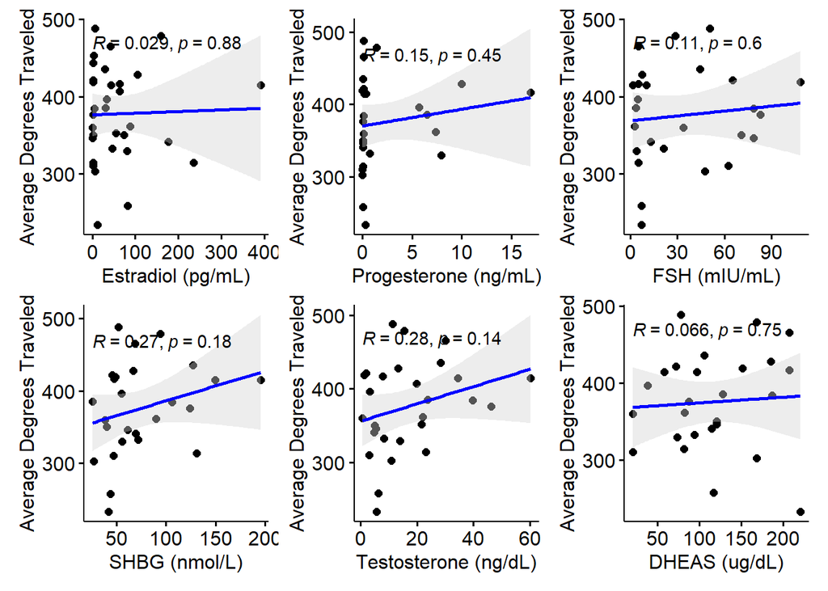

No associations between LOOP degrees traveled and hormones for women.

### MAZE

**Accuracy**

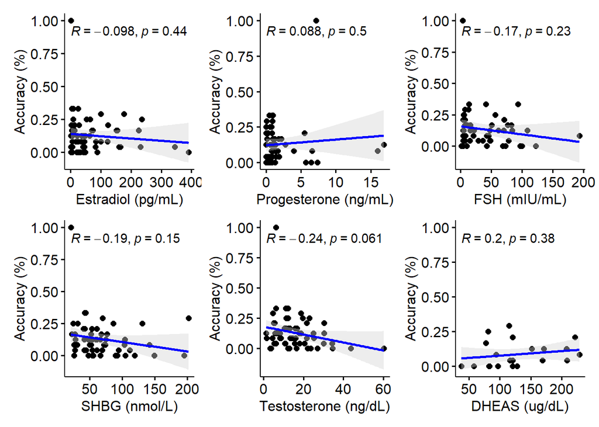

No association between MAZE accuracy and hormones for women, except negatively and marginally correlated with testosterone.

**Moves**

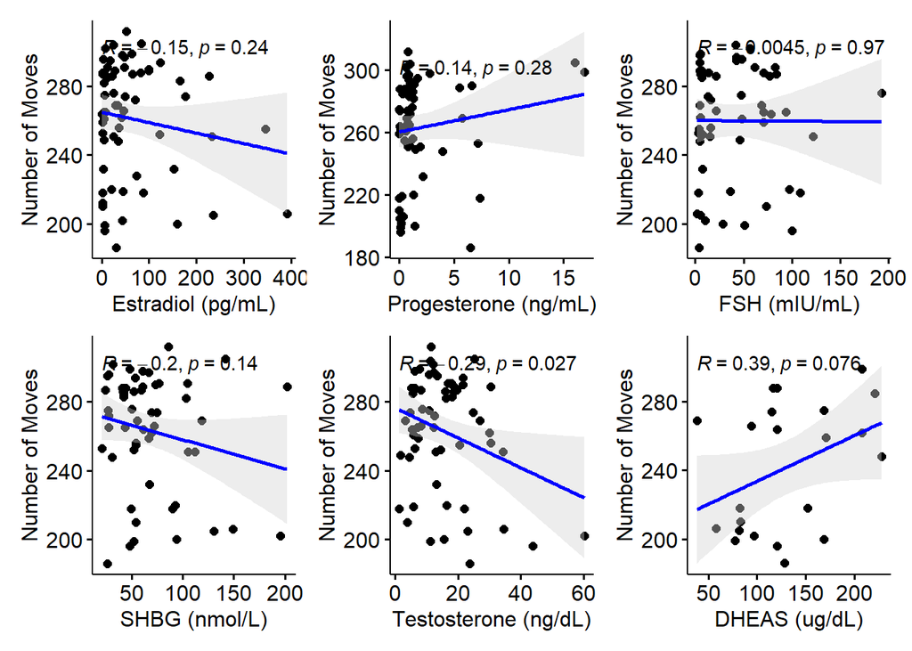

For MAZE moves, it seems to be positively, marginally associated with DHEAS and negatively associated with testosterone for women.

### DSP

**Wayfinding Success**

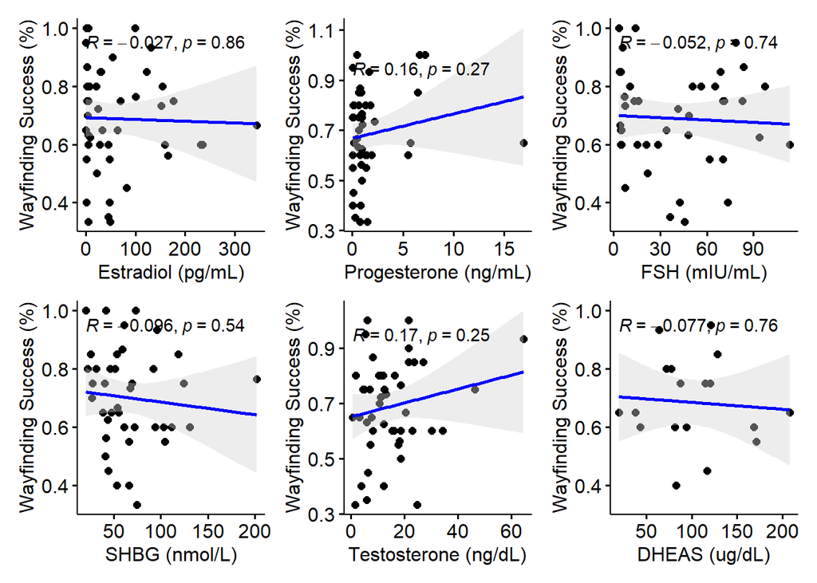

No associations between DSP wayfinding success and hormones for women.

**Solution Index**

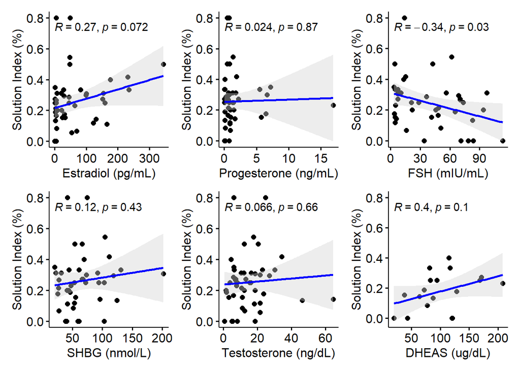

For DSP solution index, estradiol is marginally positively associated and FSH is negatively associated in women.

# Summary

Still waiting on analysis for remainder of FSH, SHBG, and DHEAS. But rerunning correlations with updated hormone data so far show:

- For LOOP position error and DHEAS, there is a positive association for men and positive marginal association for women. For degrees traveled, there is a negative marginal association between SHBG and degrees traveled for men .
- For MAZE, there are no associations for men. For women, there is a negative marginal correlation with accuracy and testosterone, and a negative correlation for moves made with testosterone.
- For DSP, there are no associations for men. For women, there is a positive marginal correlation with solution index and estradiol, and a negative correlation between solution index and FSH.

Future directions:

- Wait for the remainder of the hormones and re-evaluate with spatial navigation behaviors for men and women
- Consider other covariates like spatial navigation batteries (e.g., SBSOD) for multiple regression model.